# Classical Linear Models

1 Dec 2014

## Correlation

The correlation coefficient tells us the strength of the linear association between two variables.

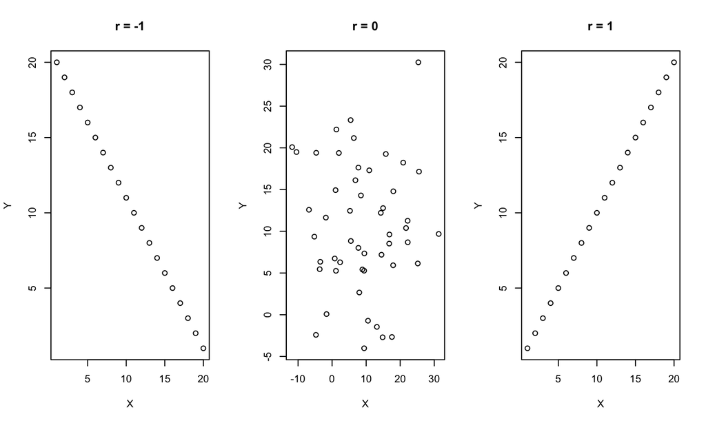

## Pearson's correlation coefficient

\(r = \frac{\sum(x-\overline{x})(y-\overline{y})}{\sqrt{\sum(x-\overline{x})^2 (y-\overline{y})^2}}\)

```r
cor.test(dahu.dat$R,dahu.dat$L)
```

```
##
##  Pearson's product-moment correlation
##
## data:  dahu.dat$R and dahu.dat$L
## t = 5.659, df = 123, p-value = 1.013e-07
## alternative hypothesis: true correlation is not equal to 0
## 95 percent confidence interval:
##  0.3031 0.5835
## sample estimates:
##    cor
## 0.4545
```

## Pearson's correlation coefficient

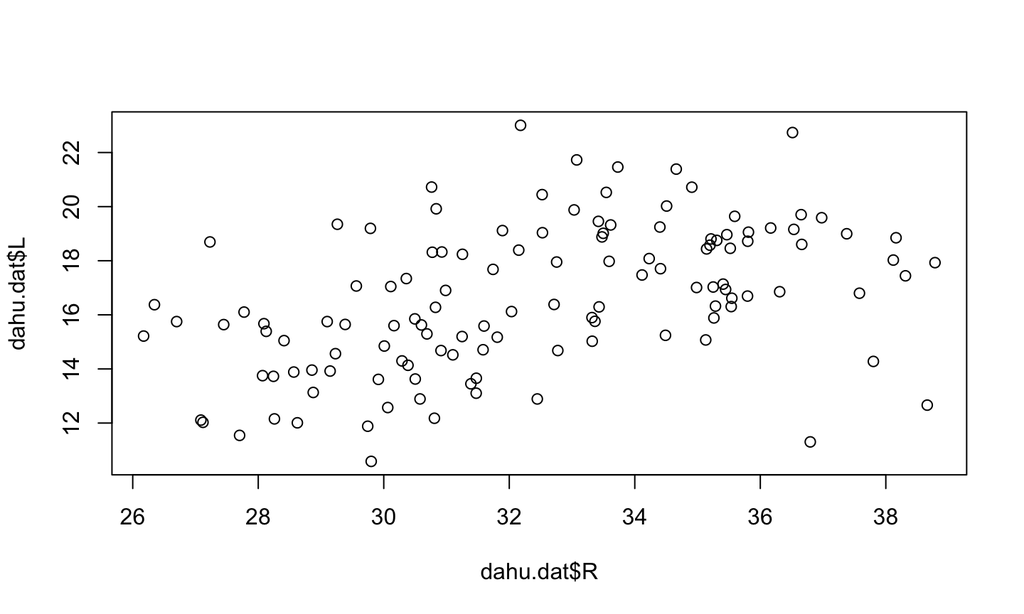

```r
plot(dahu.dat$R,dahu.dat$L)
```

## Linear regression

In linear regression we imply that one variable (X) is a **predictor** of variable Y (the **dependent** or **response** variable). x is also called **indipendent** or **explanatory** variable

\(Y_{i} = \alpha + \beta X_{i} +\epsilon_{i}\)

\(\epsilon = N(0,\sigma^2)\)

```r
dahu.lm<-lm(dahu.dat$L~dahu.dat$R)
dahu.lm
```

```
##
## Call:
## lm(formula = dahu.dat$L ~ dahu.dat$R)
##
## Coefficients:
## (Intercept)   dahu.dat$R
##       4.089        0.386
```

## Linear regression

```r
summary(dahu.lm)
```

```
##
## Call:
## lm(formula = dahu.dat$L ~ dahu.dat$R)
##
## Residuals:
##    Min     1Q Median     3Q    Max
## -7.005 -1.452 -0.021  1.344  6.481
##
## Coefficients:
##             Estimate Std. Error t value Pr(>|t|)
## (Intercept)   4.0890     2.2241    1.84    0.068 .
## dahu.dat$R    0.3864     0.0683    5.66    1e-07 ***
## ---
## Signif. codes:  0 '***' 0.001 '**' 0.01 '*' 0.05 '.' 0.1 ' ' 1
##
## Residual standard error: 2.37 on 123 degrees of freedom
## Multiple R-squared:  0.207,  Adjusted R-squared:   0.2
## F-statistic:   32 on 1 and 123 DF,  p-value: 1.01e-07
```

## Linear regression

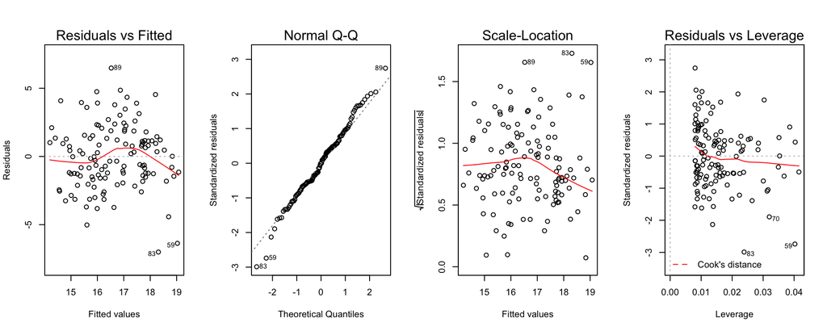

```r
par(mfrow=c(1,4))
plot(dahu.lm)
```

http://strata.uga.edu/6370/rtips/regressionPlots.html

## Do storks deliver babies?

http://www.mpcm-evolution.org/practice/online-practical-material-chapter-8

```r
storks.dat <- read.csv("storks.csv")
head(storks.dat)
```

```
##    Country   Area Storks Humans Birth
## 1  Albania  28750    100    3.2    83
## 2  Austria  83860    300    7.6    87
## 3  Belgium  30520      1    9.9   118
## 4 Bulgaria 111000   5000    9.0   117
## 5  Denmark  43100      9    5.1    59
## 6   France 544000    140   56.0   774
```

## Do storks deliver babies?

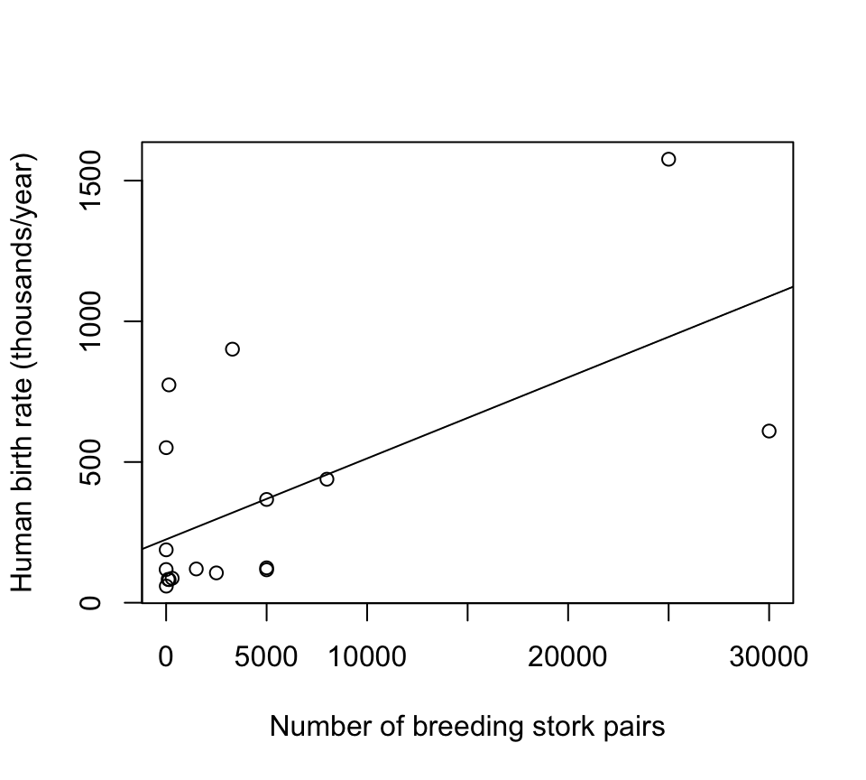

## Do storks deliver babies?

```r
summary(storks.lm)
```

```
Call:
lm(formula = Birth ~ Storks, data = storks.dat)

Residuals:
   Min     1Q Median     3Q    Max
  -479   -166   -145     -2    631

Coefficients:
            Estimate Std. Error t value Pr(>|t|)
(Intercept) 225.0287    93.5606    2.41   0.0295 *
Storks        0.0288     0.0094    3.06   0.0079 **
---
Signif. codes:  0 '***' 0.001 '**' 0.01 '*' 0.05 '.' 0.1 ' ' 1

Residual standard error: 332 on 15 degrees of freedom
Multiple R-squared:  0.385, Adjusted R-squared:  0.344
F-statistic: 9.38 on 1 and 15 DF,  p-value: 0.0079
```

## Do storks deliver babies?

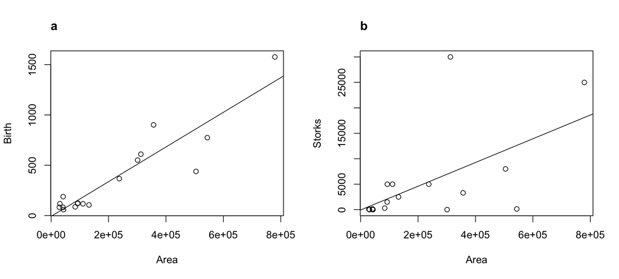

## Do storks deliver babies?

```r
storks2.lm<-lm(Birth~Area,data=storks.dat)
summary(storks2.lm)
```

```
##
## Call:
## lm(formula = Birth ~ Area, data = storks.dat)
##
## Residuals:
##    Min     1Q Median     3Q    Max
## -422.9  -49.7   -7.5   73.2  293.7
##
## Coefficients:
##              Estimate Std. Error t value Pr(>|t|)
## (Intercept) -7.775499  56.937678   -0.14     0.89
## Area         0.001723   0.000186    9.26  1.4e-07 ***
## ---
## Signif. codes:  0 '***' 0.001 '**' 0.01 '*' 0.05 '.' 0.1 ' ' 1
##
## Residual standard error: 163 on 15 degrees of freedom
## Multiple R-squared:  0.851,  Adjusted R-squared:  0.841
## F-statistic: 85.7 on 1 and 15 DF,  p-value: 1.36e-07
```

## Do storks deliver babies?

```r
storks3.lm<-lm(Storks~Area,data=storks.dat)
summary(storks3.lm)
```

```
##
## Call:
## lm(formula = Storks ~ Area, data = storks.dat)
##
## Residuals:
##    Min     1Q Median     3Q    Max
## -12479  -1594   -650   -475  22773
##
## Coefficients:
##              Estimate Std. Error t value Pr(>|t|)
## (Intercept) -6.07e+01   2.59e+03   -0.02    0.982
## Area         2.33e-02   8.47e-03    2.75    0.015 *
## ---
## Signif. codes:  0 '***' 0.001 '**' 0.01 '*' 0.05 '.' 0.1 ' ' 1
##
## Residual standard error: 7440 on 15 degrees of freedom
## Multiple R-squared:  0.336,  Adjusted R-squared:  0.291
## F-statistic: 7.58 on 1 and 15 DF,  p-value: 0.0148
```

## Forcing the intercept through the origin

```r
storks4.lm<-lm(Storks~Area-1,data=storks.dat)
summary(storks4.lm)
```

```
##
## Call:
## lm(formula = Storks ~ Area - 1, data = storks.dat)
##
## Residuals:
##    Min     1Q Median     3Q    Max
## -12462  -1643   -706   -502  22757
##
## Coefficients:
##      Estimate Std. Error t value Pr(>|t|)
## Area  0.02316    0.00571    4.06  0.00091 ***
## ---
## Signif. codes:  0 '***' 0.001 '**' 0.01 '*' 0.05 '.' 0.1 ' ' 1
##
## Residual standard error: 7200 on 16 degrees of freedom
## Multiple R-squared:  0.507,  Adjusted R-squared:  0.477
## F-statistic: 16.5 on 1 and 16 DF,  p-value: 0.000911
```

## Do storks deliver babies?

Country area seems indeed to be strongly correlated both to human birth rate and the number of stork pairs. Let's thus see what happens when we statistically control for the effect of the confounding variable Area when we include this variable in the model of the relationship between Storks and Birth:

```r
summary(lm(Birth ~ Area + Storks, data = storks.dat))
```

## Do storks deliver babies?

```
Call:
lm(formula = Birth ~ Area + Storks, data = storks.dat)

Residuals:
   Min     1Q Median     3Q    Max
-400.7  -57.5  -27.9   77.1  323.4

Coefficients:
             Estimate Std. Error t value Pr(>|t|)
(Intercept) -7.411687  56.702180   -0.13     0.90
Area         0.001583   0.000227    6.96  6.6e-06 ***
Storks       0.005995   0.005651    1.06     0.31
---
Signif. codes:  0 '***' 0.001 '**' 0.01 '*' 0.05 '.' 0.1 ' ' 1

Residual standard error: 163 on 14 degrees of freedom
Multiple R-squared:  0.862, Adjusted R-squared:  0.842
F-statistic: 43.8 on 2 and 14 DF,  p-value: 9.45e-07
```

## Multiple regression

```r
lm(Birth ~ Area + Storks, data = storks.dat)
```

\(Y_{i} = \alpha + \beta_{1} X_{1i} + \beta_{2} X_{2i} + \epsilon_{i}\)

## Polynomial regression

Polynomial regression fits a nonlinear relationship between the value of x and y. The regression function for the unknown estimated parameters, however is linear, and thus polynomial regression can be seen as a special case of multiple regression:

\(Y_{i} = \alpha + \beta_{1} X_{i} + \beta_{2} X_{i}^2 +\epsilon_{i}\)

http://datadryad.org/resource/doi:10.5061/dryad.8kb87

```r
hfc.dat<-read.table("HFC_2013_standardizzato.txt",header=T)
```

```r
hfc.lm<-lm(hfc.dat$st_weight~hfc.dat$st_age,na.action=na.omit)
summary(hfc.lm)
```

## A quadratic regression

```
##
## Call:
## lm(formula = hfc.dat$st_weight ~ hfc.dat$st_age, na.action = na.omit)
##
## Residuals:
##     Min      1Q  Median      3Q     Max
## -2.4114 -0.4713 -0.0066  0.4832  1.7701
##
## Coefficients:
##                Estimate Std. Error t value Pr(>|t|)
## (Intercept)     -0.6892     0.0514   -13.4   <2e-16 ***
## hfc.dat$st_age   0.9276     0.0488    19.0   <2e-16 ***
## ---
## Signif. codes:  0 '***' 0.001 '**' 0.01 '*' 0.05 '.' 0.1 ' ' 1
##
## Residual standard error: 0.721 on 389 degrees of freedom
##   (814 observations deleted due to missingness)
## Multiple R-squared:  0.482,  Adjusted R-squared:  0.48
## F-statistic:  362 on 1 and 389 DF,  p-value: <2e-16
```

## A quadratic regression

```r
hfc2.lm<-lm(hfc.dat$st_weight~hfc.dat$st_age+I(hfc.dat$st_age^2),na.action=na.omit)
summary(hfc2.lm)
```

```
##
## Call:
## lm(formula = hfc.dat$st_weight ~ hfc.dat$st_age + I(hfc.dat$st_age^2),
##     na.action = na.omit)
##
## Residuals:
##     Min      1Q  Median      3Q     Max
## -1.6896 -0.3768  0.0099  0.4094  1.6129
##
## Coefficients:
##                     Estimate Std. Error t value Pr(>|t|)
## (Intercept)          -0.8164     0.0451   -18.1   <2e-16 ***
## hfc.dat$st_age        1.9192     0.0919    20.9   <2e-16 ***
## I(hfc.dat$st_age^2)  -0.5489     0.0453   -12.1   <2e-16 ***
## ---
## Signif. codes:  0 '***' 0.001 '**' 0.01 '*' 0.05 '.' 0.1 ' ' 1
##
## Residual standard error: 0.615 on 388 degrees of freedom
##   (814 observations deleted due to missingness)
## Multiple R-squared:  0.624,  Adjusted R-squared:  0.622
## F-statistic:  322 on 2 and 388 DF,  p-value: <2e-16
```

## The R-squared coefficient of determination

The R-squared coefficient represents the percentage of the variation in the response variable explained by the linear model

R-squared = Explained variation / Total variation

http://blog.minitab.com/blog/adventures-in-statistics/regression-analysis-how-do-i-interpret-r-squared-and-assess-the-goodness-of-fit

## The R-squared coefficient of determination

[interactive chart not shown]

## Analysis of Variance (ANOVA)

Analysis of Variance (ANOVA) is a generalization of classical linear models, in which the independent variables are factors instead of continous variables

```r
dahu.dat$Sex<-as.factor(dahu.dat$Sex)
dahu2.lm<-lm(dahu.dat$L~dahu.dat$Sex)
```

## Analysis of Variance (ANOVA)

```r
summary(dahu2.lm)
```

```
##
## Call:
## lm(formula = dahu.dat$L ~ dahu.dat$Sex)
##
## Residuals:
##    Min     1Q Median     3Q    Max
## -6.829 -1.278  0.259  1.113  4.873
##
## Coefficients:
##               Estimate Std. Error t value Pr(>|t|)
## (Intercept)     14.868      0.275   54.00   <2e-16 ***
## dahu.dat$Sex1    3.265      0.376    8.68    2e-14 ***
## ---
## Signif. codes:  0 '***' 0.001 '**' 0.01 '*' 0.05 '.' 0.1 ' ' 1
##
## Residual standard error: 2.1 on 123 degrees of freedom
## Multiple R-squared:  0.38,   Adjusted R-squared:  0.375
## F-statistic: 75.4 on 1 and 123 DF,  p-value: 1.98e-14
```

## Analysis of Variance (ANOVA)

```r
hfc.dat$year<-as.factor(hfc.dat$year)
hfc3.lm<-lm(hfc.dat$st_weight~hfc.dat$year)
```

## Analysis of Variance (ANOVA)

```r
summary(hfc3.lm)
```

```
##
## Call:
## lm(formula = hfc.dat$st_weight ~ hfc.dat$year)
##
## Residuals:
##     Min      1Q  Median      3Q     Max
## -2.8556 -0.6298 -0.0285  0.7890  2.2302
##
## Coefficients:
##                  Estimate Std. Error t value Pr(>|t|)
## (Intercept)         0.793      0.273    2.90  0.00389 **
## hfc.dat$year2001   -1.082      0.321   -3.37  0.00082 ***
## hfc.dat$year2002   -0.917      0.318   -2.88  0.00420 **
## hfc.dat$year2003   -0.803      0.312   -2.57  0.01058 *
## hfc.dat$year2004   -1.052      0.332   -3.17  0.00167 **
## hfc.dat$year2005   -0.702      0.327   -2.15  0.03240 *
## hfc.dat$year2006   -0.707      0.321   -2.20  0.02829 *
## hfc.dat$year2007   -0.537      0.342   -1.57  0.11669
## hfc.dat$year2008   -0.474      0.347   -1.36  0.17358
## hfc.dat$year2009   -1.007      0.347   -2.90  0.00397 **
## hfc.dat$year2010   -1.145      0.325   -3.52  0.00048 ***
## hfc.dat$year2011   -0.776      0.318   -2.44  0.01532 *
## hfc.dat$year2012   -0.608      0.312   -1.95  0.05174 .
## ---
## Signif. codes:  0 '***' 0.001 '**' 0.01 '*' 0.05 '.' 0.1 ' ' 1
##
## Residual standard error: 0.984 on 378 degrees of freedom
##   (814 observations deleted due to missingness)
## Multiple R-squared:  0.0611, Adjusted R-squared:  0.0313
## F-statistic: 2.05 on 12 and 378 DF,  p-value: 0.0194
```

## Analysis of Variance (ANOVA)

```r
anova(hfc3.lm)
```

```
## Analysis of Variance Table
##
## Response: hfc.dat$st_weight
##               Df Sum Sq Mean Sq F value Pr(>F)
## hfc.dat$year  12     24   1.986    2.05  0.019 *
## Residuals    378    366   0.969
## ---
## Signif. codes:  0 '***' 0.001 '**' 0.01 '*' 0.05 '.' 0.1 ' ' 1
```

## Analysis of Variance (ANOVA)

```r
hfc.dat$year<-as.factor(hfc.dat$year)
hfc3.lm<-lm(hfc.dat$st_weight~hfc.dat$year-1)
summary(hfc3.lm)
```

```
##
## Call:
## lm(formula = hfc.dat$st_weight ~ hfc.dat$year - 1)
##
## Residuals:
##     Min      1Q  Median      3Q     Max
## -2.8556 -0.6298 -0.0285  0.7890  2.2302
##
## Coefficients:
##                  Estimate Std. Error t value Pr(>|t|)
## hfc.dat$year2000  0.79287    0.27297    2.90   0.0039 **
## hfc.dat$year2001 -0.28945    0.16879   -1.71   0.0872 .
## hfc.dat$year2002 -0.12448    0.16404   -0.76   0.4484
## hfc.dat$year2003 -0.00968    0.15187   -0.06   0.9492
## hfc.dat$year2004 -0.25899    0.18941   -1.37   0.1723
## hfc.dat$year2005  0.09111    0.17969    0.51   0.6124
## hfc.dat$year2006  0.08626    0.16879    0.51   0.6096
## hfc.dat$year2007  0.25586    0.20523    1.25   0.2133
## hfc.dat$year2008  0.31933    0.21478    1.49   0.1379
## hfc.dat$year2009 -0.21397    0.21478   -1.00   0.3198
## hfc.dat$year2010 -0.35224    0.17677   -1.99   0.0470 *
## hfc.dat$year2011  0.01714    0.16404    0.10   0.9168
## hfc.dat$year2012  0.18496    0.15009    1.23   0.2186
## ---
## Signif. codes:  0 '***' 0.001 '**' 0.01 '*' 0.05 '.' 0.1 ' ' 1
##
## Residual standard error: 0.984 on 378 degrees of freedom
##   (814 observations deleted due to missingness)
## Multiple R-squared:  0.0611, Adjusted R-squared:  0.0288
## F-statistic: 1.89 on 13 and 378 DF,  p-value: 0.0295
```